# J3_exploracion_de_datos

SGM

30/03/2021

> **IMPORTANTE** Recuerda que antes de adjuntar las librerias debes instalar los paquetes estadisticos. Para ello utiliza el código:

*install.packages(“dplyr”)* install.packages(“DHARMa”) *install.packages(“ggplot2”)* install.packages(“multcompView”) *install.packages(“lmtest”)* install.packages(“ggrepel”) *install.packages(“tidyverse”)* install.packages(“ggpubr”) *install.packages(“rstatix”)* install.packages(“broom”) *install.packages(“emmeans”)* install.packages(“extrafont”)

es recomendable que ejcutes el código anterior en la **consola** (ventana inferior izquierda).

# LIBRERIAS

```r
library(dplyr)# manipulación de datos y transferencia (piping)
library(DHARMa)# análisís de los supuestos
library(ggplot2)# gráficos
library(multcompView)# gráficos para la prueba de Tuckey HDS
library(car)# para ejecutar la prueba de Levene
library(lmtest)# Test de Breush-Pagan
library(ggrepel)# Edición de gráficos y ubicación de viñetas
library(tidyverse)# para ANCOVA
library(ggpubr)#para ANCOVA
library(rstatix)#para  ANCOVA
library(broom)#para  ANCOVA
library(emmeans)# Post hoc análisis
library(extrafont)
```

#RECAPITULACION

Importación de datos a R.

Existen varios métodos. Es importante tener en cuenta ciertos lineamientos generales:

*1. Cuál tipo de archivo quiero importar.* 2. Cuál método es el más apropiado. *3. Cuál es mi finalidad con el análisis de los datos.

Metodo 1. Importarlos usando la interfaz gráfica del usuario.

Para ello sigue los siguientes pasos

- Presiona click en “file”
- Selcciona “Import data set”
- seleciona el tipo de archivo, en este ejemplo " From excel"
- selecciona “browse” en la esquina superior derecha para encontrar el archivo
- Verifica que las variables han sido identificadas correctamente
- Presiona “import” en la esquina inferioir derecha
- !listo
- Este metodo puede ser abreviado utilizando el entorno “Environment”

```r
#metodo1<-datos
```

Método 2. Importarlo por medio de la funcion “seleccionar archivo”

- Define y asigna el nombre a tu base de datos “método2”
- selecciona la funcion read.csv
- ejecuta la función “file.choose”
- la flecha verde superior derecha en el “chunk”
- Sigue la interfaz gráfica del usuario para encontrar tu archivo. Recuerda que en este caso debe ser un .csv
- Listo.

```r
metodo2 <- read.csv(file.choose())
```

Método 3. Importarlo por medio de comando (Recomendado)

- Define y asigna el nombre a tu base de datos
- selecciona la funcion read.csv
- Escribe la ruta del archivo de interes, recuerda incorporar las comillas "“,”C:"
- Recuerda cambiar la direccion de la pleca hacia la derecha “/”, “C:/Users/SGM/Desktop”
- Incluye junto con el nombre del archivo, la extension, en este caso .csv
- Verifica los espacios, y si en los nombres de la ruta hay espacios mantenlos, de lo contrario eliminalos.
- Presiona la flecha verde superior derecha en el “chunk”
- Listo.

```r
metodo3<-read.csv("C:/Users/SGM/Desktop/datos.csv")
metodo3
```

```
##    species abundancia
## 1     azul          1
## 2     azul          2
## 3     azul          3
## 4     azul          4
## 5     azul          5
## 6     azul          6
## 7     azul          7
## 8     azul          8
## 9     azul          9
## 10    azul         10
## 11   verde         11
## 12   verde         12
## 13   verde         13
## 14   verde         14
```

[output cut: 16 more lines]

#CONTENIDO

- ANALISIS EXPLORATORIO DE DATOS
- ANDEVA O ANOVA
- REGRESION LINEAL SIMPLE
- ANCOVA

## ANALISIS EXPLORATORIO DE DATOS

### EXPLORACIÓN DE DATOS

En esta sesión aprenderemos como conducir análisis exploratorios en datos, particularmente para detectar patrones y posibles desviaciones de los supuestos necesarios para conducir pruebas estadísticas. Los datos pueden ser representados y resumidos de muchas formas en R. Como ya lo habrás notado en nuestra sesión previa, el uso de gráficos durante el análisis exploratorio es de gran utilidad para validar la distribution y posibles tendencias de nuestros datos. Además puede proveer indicios de como ajustar tus datos en caso de que no correspondan con los supuestos. Recuerda **NUNCA PASES POR ALTO LOS ANÁLISIS EXPLORATORIOS** esto puede salvarte mucho tiempo y evitar interpretaciones tendenciosas y no justificadas.

#### LOS DATOS

Para esta sesión vamos a utlizar la base de datos **“iris”** que se encuentra adjunta en r, por lo tanto no necesitas cargarla. Esta base de datos presenta 5 variables.

Definamos las variables: **Sepal.Length** La longitud de los sépalos en centímetros **Sepal.Width** El ancho de los los sépalos en centímetros **Petal.Length** La longitud de los pétalos en centímetros **Petal.Width** El ancho de los pétalos en centímetros **Species** Las especies estudiadas

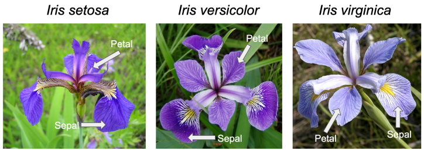

Fuente: ICHI.PRO

### EL PRIMER ACERCAMIENTO

```r
#glance(iris)
#head(iris)
#tail(iris)
#glimpse(iris)
#View(iris)# no recomendada para procesos de replicabilidad porque tiene conflictos con Knitting
summary(iris)
```

```
##   Sepal.Length    Sepal.Width     Petal.Length    Petal.Width
##  Min.   :4.300   Min.   :2.000   Min.   :1.000   Min.   :0.100
##  1st Qu.:5.100   1st Qu.:2.800   1st Qu.:1.600   1st Qu.:0.300
##  Median :5.800   Median :3.000   Median :4.350   Median :1.300
##  Mean   :5.843   Mean   :3.057   Mean   :3.758   Mean   :1.199
##  3rd Qu.:6.400   3rd Qu.:3.300   3rd Qu.:5.100   3rd Qu.:1.800
##  Max.   :7.900   Max.   :4.400   Max.   :6.900   Max.   :2.500
##        Species
##  setosa    :50
##  versicolor:50
##  virginica :50
##
##
##
```

Es importante notar que para los factores y variables lógicas, la función summary nos retorna el número de observaciones en cada nivel. Para variables numéricas (ambos enteros y con decimales), se retorna el mínimo, máximo, primer y tercer quartil la media y la mediana. Aunque es un forma fácil la desventaja es que no muestra los datos por grupo, en este caso especie. Además, en muchos casos entender nuestros datos basado estos números nos llevaría un poco de tiempo.

Existe una alternativa que nos permite evaluar otros aspectos de la base de datos, la función str()

```r
str(iris)
```

```
## 'data.frame':    150 obs. of  5 variables:
##  $ Sepal.Length: num  5.1 4.9 4.7 4.6 5 5.4 4.6 5 4.4 4.9 ...
##  $ Sepal.Width : num  3.5 3 3.2 3.1 3.6 3.9 3.4 3.4 2.9 3.1 ...
##  $ Petal.Length: num  1.4 1.4 1.3 1.5 1.4 1.7 1.4 1.5 1.4 1.5 ...
##  $ Petal.Width : num  0.2 0.2 0.2 0.2 0.2 0.4 0.3 0.2 0.2 0.1 ...
##  $ Species     : Factor w/ 3 levels "setosa","versicolor",..: 1 1 1 1 1 1 1 1 1 1 ...
```

En este caso nos muestra el tipo de variable y algunos detalles sobre ellas.

Otra forma de explorar nuestros datos consiste en detectar si hay valores incompletos o no reportados en nuestra base de datos. Para ello se utiliza la función is.na() que puede ser aplicada a toda la matriz o a una variable en particular

```r
head(is.na(iris))
```

```
##      Sepal.Length Sepal.Width Petal.Length Petal.Width Species
## [1,]        FALSE       FALSE        FALSE       FALSE   FALSE
## [2,]        FALSE       FALSE        FALSE       FALSE   FALSE
## [3,]        FALSE       FALSE        FALSE       FALSE   FALSE
## [4,]        FALSE       FALSE        FALSE       FALSE   FALSE
## [5,]        FALSE       FALSE        FALSE       FALSE   FALSE
## [6,]        FALSE       FALSE        FALSE       FALSE   FALSE
```

```r
is.na(iris$Sepal.Length)
```

```
##   [1] FALSE FALSE FALSE FALSE FALSE FALSE FALSE FALSE FALSE FALSE FALSE FALSE
##  [13] FALSE FALSE FALSE FALSE FALSE FALSE FALSE FALSE FALSE FALSE FALSE FALSE
##  [25] FALSE FALSE FALSE FALSE FALSE FALSE FALSE FALSE FALSE FALSE FALSE FALSE
##  [37] FALSE FALSE FALSE FALSE FALSE FALSE FALSE FALSE FALSE FALSE FALSE FALSE
##  [49] FALSE FALSE FALSE FALSE FALSE FALSE FALSE FALSE FALSE FALSE FALSE FALSE
##  [61] FALSE FALSE FALSE FALSE FALSE FALSE FALSE FALSE FALSE FALSE FALSE FALSE
##  [73] FALSE FALSE FALSE FALSE FALSE FALSE FALSE FALSE FALSE FALSE FALSE FALSE
##  [85] FALSE FALSE FALSE FALSE FALSE FALSE FALSE FALSE FALSE FALSE FALSE FALSE
##  [97] FALSE FALSE FALSE FALSE FALSE FALSE FALSE FALSE FALSE FALSE FALSE FALSE
## [109] FALSE FALSE FALSE FALSE FALSE FALSE FALSE FALSE FALSE FALSE FALSE FALSE
## [121] FALSE FALSE FALSE FALSE FALSE FALSE FALSE FALSE FALSE FALSE FALSE FALSE
## [133] FALSE FALSE FALSE FALSE FALSE FALSE FALSE FALSE FALSE FALSE FALSE FALSE
## [145] FALSE FALSE FALSE FALSE FALSE FALSE
```

Por ejemplo, imagina que en la base de datos iris, existe un factor que ya no es de interés, como una especie que ya no se desea estudiar y quieres quitarla de tu base de datos. Como en este caso es solo un ejercicio, y en realidad no quiero modificar la base de datos, voy a crear una copia con un nuevo nombre para remover la especie setosa de la variable Species. Esta nueva base se llamará iris_no_setosa

```r
iris_no_setosa=iris[!(iris$Species=="setosa"),]
iris_no_setosa
```

```
##     Sepal.Length Sepal.Width Petal.Length Petal.Width    Species
## 51           7.0         3.2          4.7         1.4 versicolor
## 52           6.4         3.2          4.5         1.5 versicolor
## 53           6.9         3.1          4.9         1.5 versicolor
## 54           5.5         2.3          4.0         1.3 versicolor
## 55           6.5         2.8          4.6         1.5 versicolor
## 56           5.7         2.8          4.5         1.3 versicolor
## 57           6.3         3.3          4.7         1.6 versicolor
## 58           4.9         2.4          3.3         1.0 versicolor
## 59           6.6         2.9          4.6         1.3 versicolor
## 60           5.2         2.7          3.9         1.4 versicolor
## 61           5.0         2.0          3.5         1.0 versicolor
## 62           5.9         3.0          4.2         1.5 versicolor
## 63           6.0         2.2          4.0         1.0 versicolor
## 64           6.1         2.9          4.7         1.4 versicolor
```

[output cut: 86 more lines]

Listo, esta base de datos no contiene el factor setosa en la variable especie. Sin embargo cada vez que realizamos este proceso es necesario declarar la variable modificada como factor, para que el factor sea removido efectivamente

```r
levels(iris_no_setosa$Species)
```

```
## [1] "setosa"     "versicolor" "virginica"
```

```r
iris_no_setosa=iris_no_setosa %>% mutate(Species=factor(Species))
levels(iris_no_setosa$Species)
```

```
## [1] "versicolor" "virginica"
```

### GRÁFICOS

Representar nuestros datos graficamente es la mejor manera de determinar la distribución, detectar valores anómalos o extremos y patrones relevantes en nuestros datos antes de seleccionar un análisis. Además, nos puede indicar las posibles soluciones que debemos aplicar a nuestros datos en caso de ser necesario o dar pistas sobre análisis que podriamos ejecutar para obtener mayor información de ellos.

La gran mayoría de análisis requiere que los datos 1. Hayan sido colectados por medio de Muestreo Aleatorio Simple (Dificil de lograr en biología), pero necesario 2. Cada observación sea independiente El diseño del experimento es esencial para una buena y investigación y los análisis, incluso los más robustos, no pueden compensar las carencias dejadas por un diseño sesgado, débil y erróneo. Por lo tanto es importante dar enfásis a este paso. Esto no será estudiado en este curso, pero vale la pena mencionar que antes de colectar tus datos, diseñes tu experimento. BUsca ayuda con alguin con experiencia y pricipalmente con personas en el área de estadística.

Para ejecutar la mayoría de los análisis necesitamos, comunmente

3. Normalidad
4. Homogeneidad de varianza

En técnicas mas avanzadas (no cubiertas en este curso) hay métodos que pueden corregir e incorporar conjuntos de observaciones que no cumplen con el supuesto de independencia como los Modelos Generalizados Lineales Mixtos o Generalized Linear Mixed Models en inglés (GLMM)

#### Histograma

El histograma de frecuencias es una alterniva excelente para observar la distribucion de variables continuas. Presenta una idea rapida de si los datos se ajustan a una distribucion normal y la presencia de valores extremos. Construyamos un histograma para nuestras variables númericas continuas.

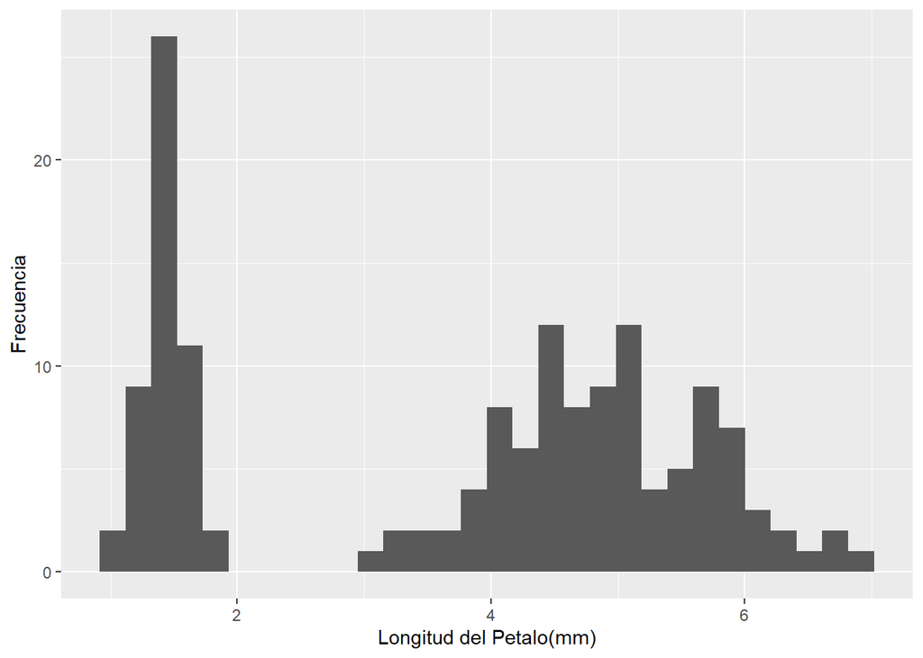

```r
#png("figura 1", units="in", width=10, height=7, res=300)
histograma1<-ggplot(data=iris, aes(Petal.Length))+
  geom_histogram()+ #Draw histogram with probabilities
  xlab("Longitud del Petalo(mm)")+
  ylab("Frecuencia")
histograma1
```

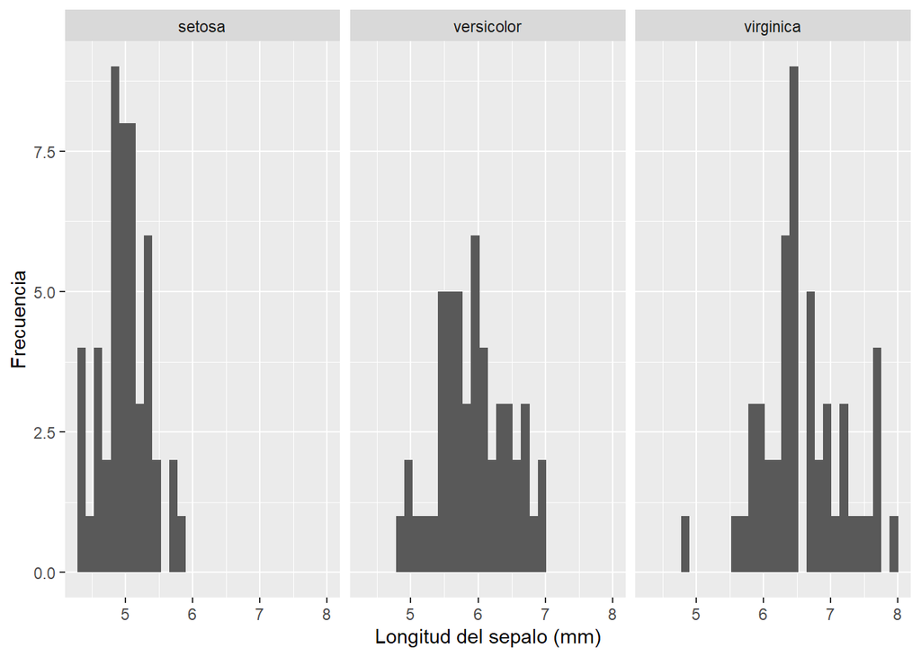

```r
histograma2<-ggplot(data=iris, aes(Sepal.Length))+
  geom_histogram()+ #Draw histogram with probabilities
  xlab("Longitud del sepalo (mm)")+
  ylab("Frecuencia")+
facet_wrap(~Species)
histograma2
```

#### Gráfico de Cajas y Bigotes

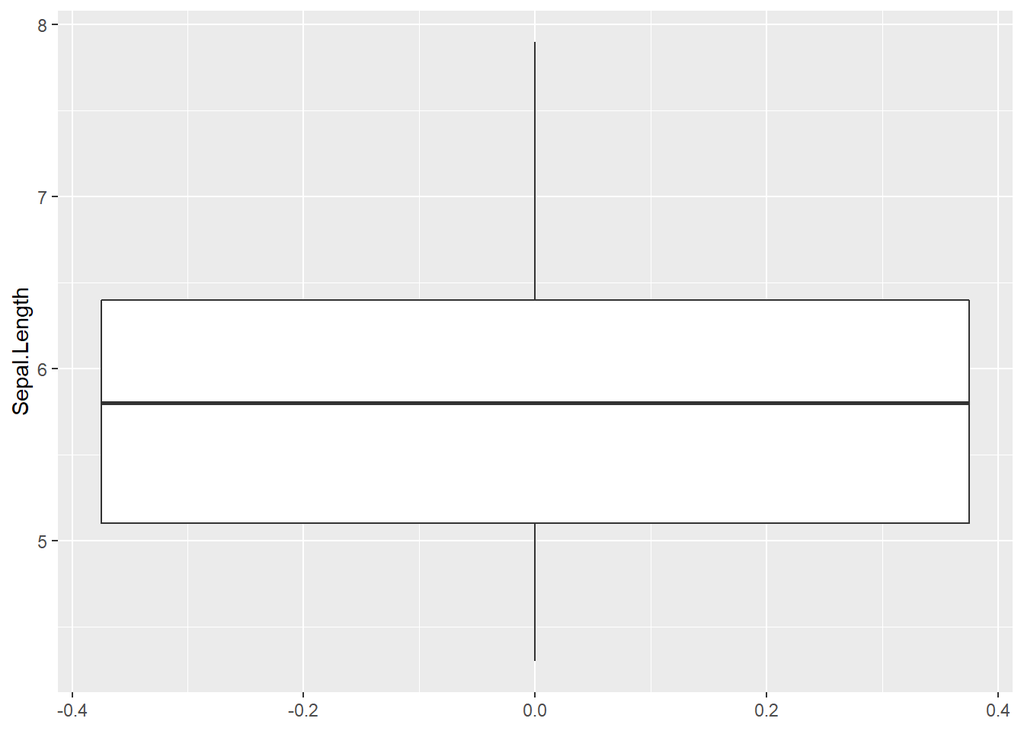

```r
Cajas_y_bigotes<-ggplot(data=iris, aes(y=Sepal.Length))+
  geom_boxplot()


Cajas_y_bigotes
```

```r
 # # ejemplovio<-ggplot(data=iris, aes(x=Species, y=Sepal.Length, fill=Species))+
 #   geom_violin()+
 #    coord_flip()+
 #   stat_summary(fun.y=median, geom="point", size=2, color="black")
 #
 # ejemplovio
```

Aun no es claro…

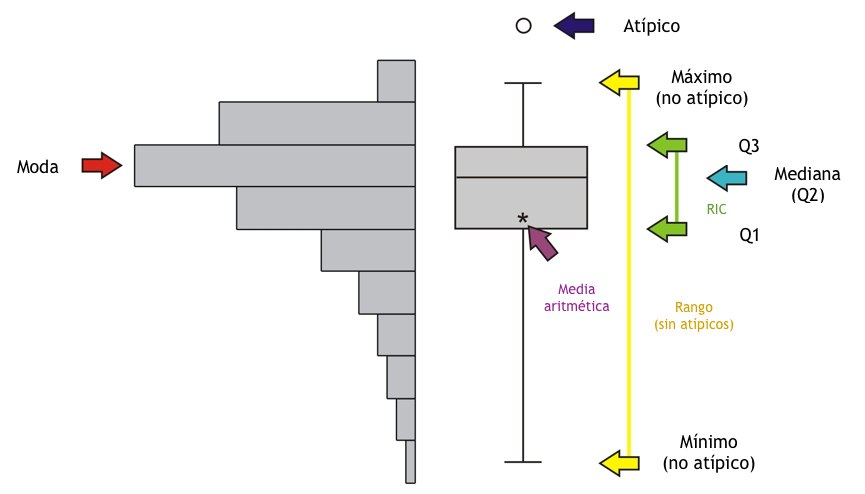

Seria ahora interesante ver como se comportan estos datos entre las especies.

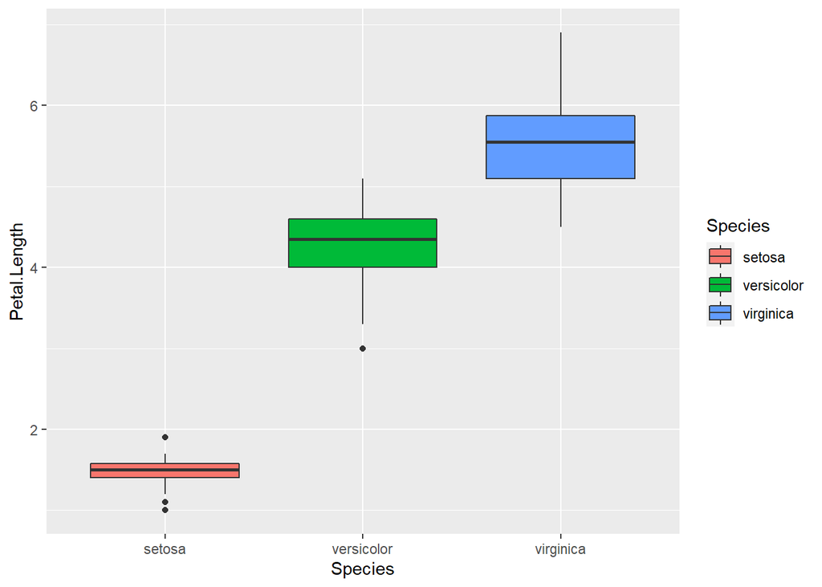

```r
Cajas_y_bigotes2<-ggplot(data=iris, aes(y=Petal.Length, x=Species, fill=Species))+
  geom_boxplot()
Cajas_y_bigotes2
```